# sample() and distributions

Robert Cope

10/08/2020

This document (also available in video form on Echo360 if you prefer) provides some information on useful functions that involve randomness. Randomness is an important part of statistics and enables a lot of powerful ideas.

## sample()

sample() is a function that takes a vector, and a number of elements, and returns a random sample (of the specified number of elements) from that vector. Think of it like putting the elements of the vector into a bag, and then drawing out one-at-time until you’ve got as many as you need. For example:

```r
x <- seq(1, 10)
sample(x, 5)
```

```
## [1]  1 10  6  4  9
```

Every time you do this, you get a different (random) sample from your vector:

```r
for(i in seq(1,10)){
  print(sample(x,5))
}
```

```
## [1]  9  8  7 10  5
## [1]  2  6  9 10  4
## [1] 8 7 2 6 1
## [1]  1  3  4 10  2
## [1] 7 9 4 8 3
## [1]  1  4  5 10  7
## [1]  4  5  6 10  1
## [1]  5  3 10  6  7
## [1] 10  4  7  6  8
## [1] 8 9 6 2 4
```

(note that for() loops are covered in the other pre-reading this week)

On thing you will note, is that by default, you can’t get the same element from the vector twice. This is called sampling without replacement (i.e., you are not replacing the item in the bag after you pull it out).

```r
sample(x,10)
```

```
##  [1]  7  6  9  4  8  5  1  2  3 10
```

If instead you want to sample *with* replacement, you can set the argument `replace = TRUE`.

```r
sample(x,10, replace=TRUE)
```

```
##  [1]  3  7 10  5 10 10  4  3 10  8
```

## Random distributions.

Previously we have seen `rnorm()`. If you look at its help file (using `?rnorm`) you see that the page describes four functions, each relating to the normal distribution. R understands many distributions for random variables, and this pattern of four functions is common to all of them. We will go through each of them.

### rnorm()

`rnorm()` allows you to generate random numbers from a normal distribution (i.e., the r stands for random, and norm denotes the distribution). As arguments you give it the number of random numbers you want, and also a mean and standard deviation (by default these are 0 and 1 respectively). We can then use these generated random numbers in whatever way we would like, e.g., by plotting them.

```r
library(tidyverse) # to create tibbles / use ggplot
rn_df <- tibble(x = rnorm(10000, mean = 10, sd = 2))
#I put it in a tibble so I can plot it
rn_df
```

```
## # A tibble: 10,000 x 1
##        x
##    <dbl>
##  1 11.5
##  2  9.34
##  3  9.94
##  4 11.9
##  5  5.36
##  6 10.4
##  7  9.58
##  8 10.2
##  9 12.9
## 10  5.43
## # … with 9,990 more rows
```

```r
summary(rn_df)
```

```
##        x
##  Min.   : 3.093
##  1st Qu.: 8.652
##  Median : 9.971
##  Mean   : 9.983
##  3rd Qu.:11.339
##  Max.   :17.949
```

geom_density() gives what is (basically) a smoothed histogram of the data and is a natural choice for numbers that could take any decimal value, like this.

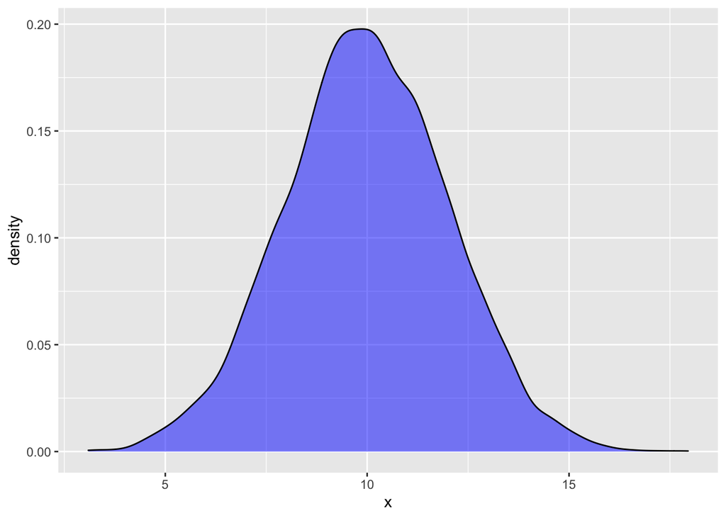

```r
ggplot(rn_df,aes(x=x))+
  geom_density(fill = 'blue', alpha = 0.5)
```

### dnorm()

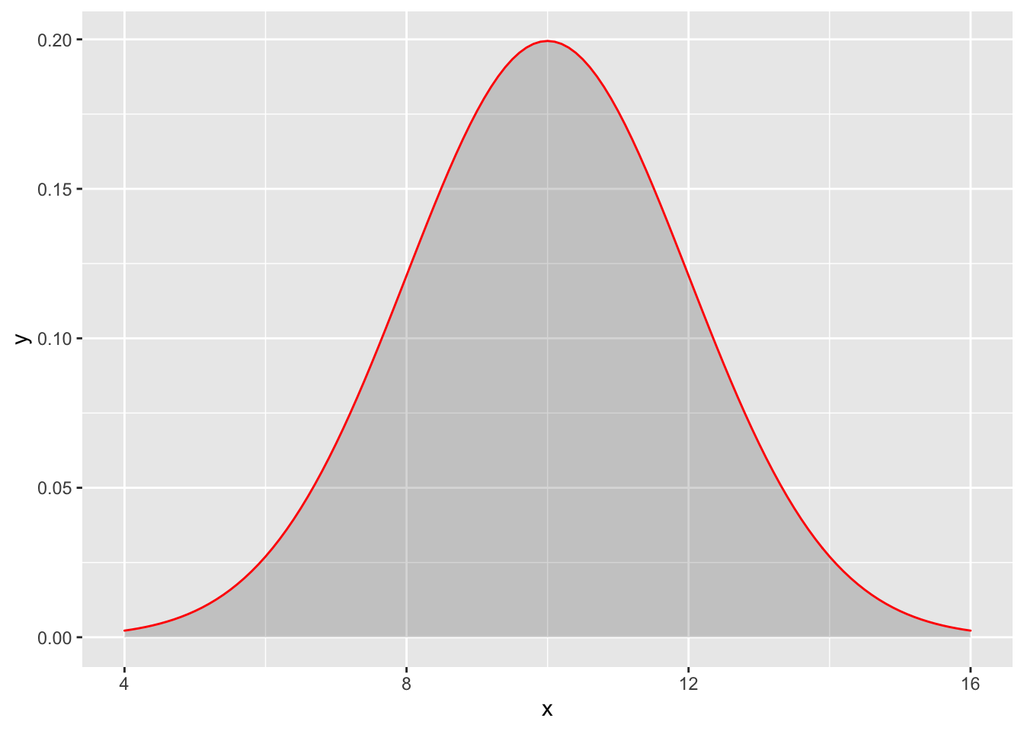

```r
dn_df <- tibble(x=seq(from = 4, to = 16, by = 0.1), y = dnorm(x, mean = 10, sd =2))

ggplot(dn_df, aes(x=x,y=y))+
  geom_area(col='red', alpha = 0.2)
```

If we plot both on top of each other, we see that they are close – the red line is the theoretical distribution (from dnorm()), and the blue area is a random sample (from rnorm()).

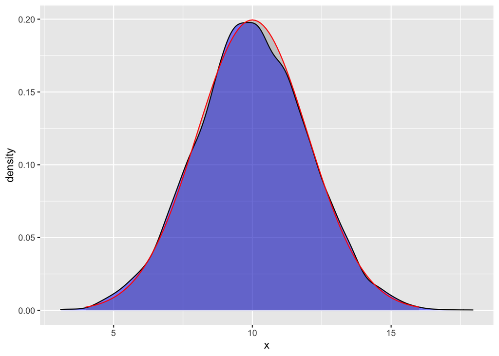

```r
ggplot(rn_df,aes(x=x))+
  geom_density(fill = 'blue', alpha = 0.5) +
  geom_area(data = dn_df, aes(y = y), col='red', alpha = 0.2)
```

### qnorm() and pnorm()

`qnorm()` and `pnorm()` are opposites – qnorm gives the values at theoretical quanties of the distribution, and pnorm gives the probability distribution at a given point. So, imagine we want to know where the 11%, 50% and 89% quantiles of the distribution are – we could use qnorm().

```r
qn_df <- tibble(quantiles = c(0,0.11, 0.5, 0.89,1.0),
                x = qnorm(quantiles, mean = 10, sd = 2))
qn_df
```

```
## # A tibble: 5 x 2
##   quantiles       x
##       <dbl>   <dbl>
## 1      0    -Inf
## 2      0.11    7.55
## 3      0.5    10
## 4      0.89   12.5
## 5      1     Inf
```

So, 11% of the distribition is below 7.55, 50% is below 10, and 89% is below 12.5.

We could compare this to the random values we generated earlier, and see that these are quite to what we expect:

```r
rn_df %>%
  mutate(bins = cut(x, breaks = qn_df$x)) %>%
  group_by(bins) %>%
  summarise(count = n()) %>%
  mutate(observed_proportion = count / sum(count))
```

```
## # A tibble: 4 x 3
##   bins        count observed_proportion
##   <fct>       <int>               <dbl>
## 1 (-Inf,7.55]  1149               0.115
## 2 (7.55,10]    3911               0.391
## 3 (10,12.5]    3836               0.384
## 4 (12.5, Inf]  1104               0.110
```

`pnorm()` does the reverse, so we could use it to get back to our original quantiles:

```r
pnorm(qn_df$x,mean = 10, sd = 2)
```

```
## [1] 0.00 0.11 0.50 0.89 1.00
```

And we can include these on our figure:

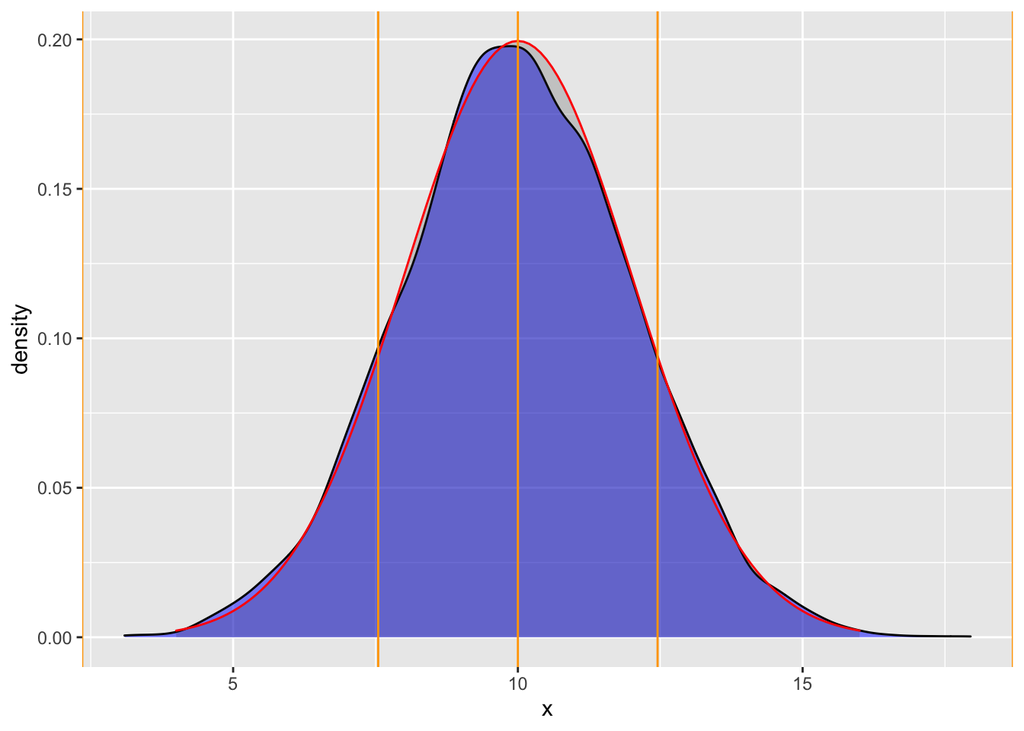

```r
ggplot(rn_df,aes(x=x))+
  geom_density(fill = 'blue', alpha = 0.5) +
  geom_area(data = dn_df, aes(y = y), col='red', alpha = 0.2)+
  geom_vline(data = qn_df, aes(xintercept = x),col='orange')
```

## Other distributions

The same pattern holds for other distributions. For example, we could do the same thing (with appropriately chosen values) with the uniform distribution:

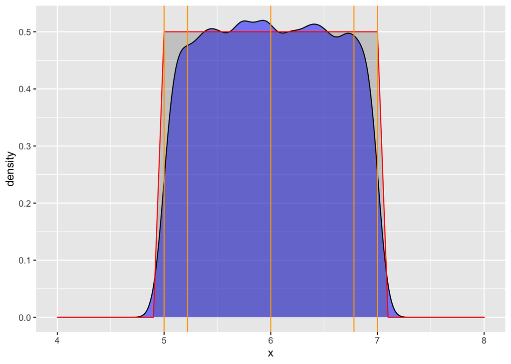

```r
rU_df <- tibble(x = runif(10000,min = 5, max = 7))
dU_df <- tibble(x=seq(from = 4, to = 8, by = 0.1), y = dunif(x,min = 5, max = 7))
qU_df <- tibble(quantiles = c(0,0.11, 0.5, 0.89,1.0),
                x = qunif(quantiles,min = 5, max = 7))

ggplot(rU_df,aes(x=x))+
  geom_density(fill = 'blue', alpha = 0.5) +
  geom_area(data = dU_df, aes(y = y), col='red', alpha = 0.2)+
  geom_vline(data = qU_df, aes(xintercept = x),col='orange')
```

Note that geom_density() tries to smooth the data which doesn’t work too well at the very sharp boundaries of this distribution.

Or the gamma distribution:

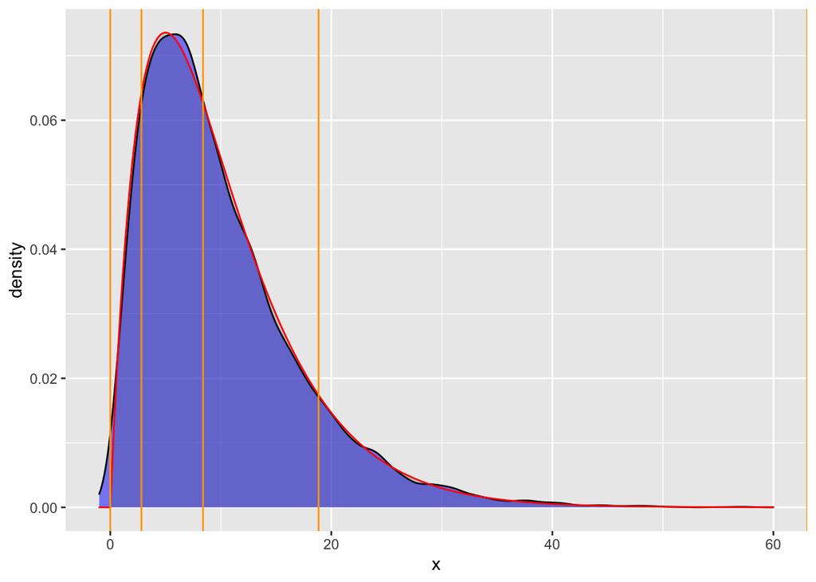

```r
rG_df <- tibble(x = rgamma(10000,shape = 2, scale = 5))
dG_df <- tibble(x=seq(from = -1, to = 60, by = 0.1), y = dgamma(x,shape = 2, scale = 5))
qG_df <- tibble(quantiles = c(0,0.11, 0.5, 0.89,1.0),
                x = qgamma(quantiles,shape = 2, scale = 5))

ggplot(rG_df,aes(x=x))+
  geom_density(fill = 'blue', alpha = 0.5) +
  geom_area(data = dG_df, aes(y = y), col='red', alpha = 0.2)+
  geom_vline(data = qG_df, aes(xintercept = x),col='orange')
```

This would also work with a discrete distribution (e.g., the binomial distribution), but in that case the random variable can only take integer (i.e., whole number, 0, 1, 2, etc.) values and so you should be careful when plotting etc..